# Python_tutorial_03

Ji-Myoung Choi

2022-12

## 웹 스크래핑(scraping) 기초: requests and BeautifulSoup

- 간단한 웹페이지를 스크래핑하여 파싱하는 방법을 배운다.
- 웹과의 통신을 도와주는 requests 라이브러리와 받은 웹 문서를 파싱(parsing)하는 BeautifulSoup 라이브러리를 이용한다.

#### 1. 웹페이지 요청하기

- “The Adventures of Sherlock Holmes” (by Arthur Conan Doyle) (https://ko.wikipedia.org/wiki/%EC%85%9C%EB%A1%9D_%ED%99%88%EC%A6%88%EC%9D%98_%EB%AA%A8%ED%97%98)

```python
# !pip install requests
import requests
```

1. 2행: **requests** 라이브러리를 탑재한다. 만약 ModuleNotFoundError 에러가 나면
2. 1행: !pip install requests 를 실행하여 라이브러리를 설치한 후 다시 탑재한다.

```python
url = 'https://www.gutenberg.org/cache/epub/1661/pg1661-images.html'
resp = requests.get(url)
print(resp.status_code)
```

```
## 200
```

1. 1행: 가져오고 싶은 웹페이지의 주소를 *url* 변수에 저장한다.
2. 2행: **requests** 라이브러리의 **get()** 함수에 *url* 정보를 주어 웹페이지를 요청하고 요청 결과를 *resp*에 저장한다.
3. 3행: 요청이 올바로 이루어졌는지 resp.status_code를 출력한다. 만약 200이 출력되면 정상적으로 요청이 이루어지고 웹페이지를 받아온 것이다.

#### 2. 요청한 웹 페이지에서 필요 요소 추출하기

```python
# !pip install beautifulsoup4
from bs4 import BeautifulSoup
```

1. 2행: 받아온 엡 페이지를 분석하여 필요한 요소들을 추출하기 위해 필요한 도구인 BeautifulSoup을 탑재한다. BeautifulSoup은 bs4 라이브러리 중의 일부이므로 필요한 일부 기능만 *from* bs4 *import* BeautifulSoup 명령으로 탑재한다. 만약 ModuleNotFoundError 에러가 나면
2. 1행: !pip install beautifulsoup4를 실행하여 라이브러리를 설치한 후 다시 탑재한다.

```python
url = 'https://www.gutenberg.org/cache/epub/1661/pg1661-images.html'
page = requests.get(url)
page_content = page.content
# page_content = page.content.decode('utf-8')

parsed_page = BeautifulSoup(page_content, 'html.parser')
```

1. 1행: 가져오고 싶은 웹페이지의 주소를 *url* 변수에 저장한다.
2. 2행: **requests** 라이브러리의 **get()** 함수에 *url* 정보를 주어 웹페이지를 요청하고 요청 결과를 *page*에 저장한다.
3. 3행: *page* 객체에서 html 웹 페이지(*content*)만 따로 떼어내어 *page_content* 변수에 저장한다.
4. 6행: **BeautifulSoup()** 함수로 가져온 웹 페이지의 구조를 분석한다. 이 함수의 첫 번째 항은 *page* 객체에서 가져온 *page_content* 즉 분석 대상 웹 페이지이고, 두 번째 항은 구조 분석을 위한 분석기 이름이다. 웹 페이지를 분석할 것이므로 분석기 이름은 **html.parser**이다. 만약 XML 파일을 분석하고자 한다면 **lxml** 분석기를 이용한다(lxml 사용을 위해서는 !pip install lxml 명령으로 해당 패키지를 설치해 주어야 한다). 분석이 끝난 내용을 *parsed_page*에 저장한다.

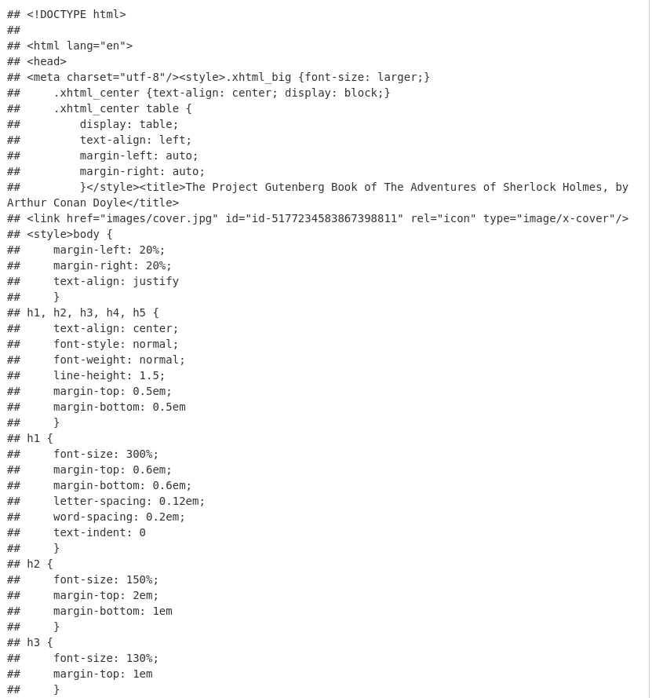

1. *parsed_page*를 출력하면 태그와 속성, 텍스트로 구성된 웹 페이지의 구조를 볼 수 있다. 브라우저로 해당 웹 페이지를 방문 후 페이지 위에 커서를 놓고 오른 클릭을 하면 View page source와 Inspect 메뉴가 있는데(모든 브라우저 공통), Inspect를 선택하면 웹 페이지에 프레임이 생기면서 오른 편이나 하단에 웹 페이지 소스창이 생긴다. 여기서 볼 수 있는 소스 정보가 parsed_page와 같다.

#### 3. 웹페이지에서 정보 추출하기(1)

분석이 완료된 웹페이지 정보는 태그 이름을 이용하여 내용을 확인할 수 있다. 만약 <title>…</title> 내용을 확인하고 싶으면 다음과 같이 분석 완료된 웹 데이터 다음에 **.태그명** 을 붙이면 된다.

```python
print(parsed_page.title)
```

```
## <title>The Project Gutenberg Book of The Adventures of Sherlock Holmes, by Arthur Conan Doyle</title>
```

1. 1행: *parsed_page* 중에서 처음으로 나타나는 <title>…</title> 태그 정보를 가져와서 출력한다.

[figure not shown]

**그러나 위의 방법은 복잡한 웹 페이지의 구조에서 정보를 추출하기에 비효율적인 방법이다. **find()**, **find_all()**, **select()** 등의 함수를 이용하여 정보를 추출하는 것이 보다 효율적이다. 웹 브라우저에서 페이지 구조를 열어 원하는 정보의 태그를 확인하여 이 태그들만 추출하여 정보를 얻는 것이 효율적이다.**

#### 3. 웹페이지에서 정보 추출하기(2)

##### 제목과 서지 정보 등을 제외하고 소설의 본문만 가져오기

- 웹 페이지에서 가져오고 싶은 내용이 페이지의 소스에서 어떻게 표현되는지를 알려면 가져오고 싶은 부분을 일부 영역 선택한 후에 마우스 오른 클릭을 하고 Inspect 메뉴를 선택한다. 오른쪽 혹은 하단에서 나타나는 웹페이지의 소스 정보(Elements 정보)에서 해당 부분의 태그 위치가 반전되어 해당 부분의 태그를 찾을 수 있다.

[figure not shown]

- 소설의 본문은 모두 <p>…</p> 태그로 둘러싸여 있음을 알 수 있다. 이 <p>…</p> 사이의 내용을 모두 가져오면 소설의 본문을 텍스트 파일로 만들 수 있다.

|웹 페이지에서 사용하는 태그의 구조는 대개 다음과 같다.

```
<div class='title' style='width:65%;'>TITLE_1</div>
```

```python
paras = parsed_page.find_all(name='p')
print("All paragraph length is", len(paras), "\n")
```

```
## All paragraph length is 2539
```

```python
for para in paras[:5]:
    print(para.get_text())
```

```
## Title: The Adventures of Sherlock Holmes
## Author: Arthur Conan Doyle
## Release Date: March 1, 1999 [EBook #1661]
## Language: English
##
## To Sherlock Holmes she
## is always the woman. I have seldom heard him mention her under any other
## name. In his eyes she eclipses and predominates the whole of her sex. It was
## not that he felt any emotion akin to love for Irene Adler. All emotions, and
## that one particularly, were abhorrent to his cold, precise but admirably
## balanced mind. He was, I take it, the most perfect reasoning and observing
## machine that the world has seen, but as a lover he would have placed himself in
## a false position. He never spoke of the softer passions, save with a gibe and a
## sneer. They were admirable things for the observer—excellent for drawing
## the veil from men’s motives and actions. But for the trained reasoner to
## admit such intrusions into his own delicate and finely adjusted temperament was
## to introduce a distracting factor which might throw a doubt upon all his mental
## results. Grit in a sensitive instrument, or a crack in one of his own
## high-power lenses, would not be more disturbing than a strong emotion in a
## nature such as his. And yet there was but one woman to him, and that woman was
## the late Irene Adler, of dubious and questionable memory.
```

1. 1행: **find_all()** 함수로 <p> 태그를 모두 찾아 *paras*에 저장한다. **find_all()**은 검색 대상인 첫 번째 항(name=)에 지정된 태그를 모두 가져온다. 위에서는 <p> 태그 이름을 기입하였다.
2. 2행: *paras*의 갯수, 즉 <p> 태그의 갯수를 확인한다. 총 2,539개의 <p>…</p> 태그가 검색되었다.
3. 4행: 전체 *paras* 중에서 처음 5개만 슬라이싱하여 하나씩 *para*에 할당하고, 각 *para*에 대해
4. 5행: *para* 내의 텍스트, 즉 <p>…</p>로 둘러싸인 텍스트를 출력한다. 태그를 제외하고 태그로 둘러싸인 텍스트를 가져오려면 **get_text()** 함수를 이용한다. 출력 결과, 본문 외에 서지 정보(**Title: ~ Language:**)도 같이 포함되어 있음을 알 수 있다. **get_text()** 함수는 **find**로 검색한 태그 정보에서 태그 사이에 둘러싸인 텍스트만 추출한다.

서지 정보를 제외하고 순수 본문만 추출하기 위해 추출 대상의 범위를 좁혀야 한다. 웹 페이지 소스를 잘 살펴보면 순수 본문 즉 *body*에 속하는 <p>…</p> 태그는 <div class=‘chapter’>…</div>로 둘써싸여 있음을 알 수 있다. 따라서 각 chapter를 먼저 추출하고 이 chapter들에서 <p>를 추출하면 순수 본문만 추출할 수 있다.

```python
chapters = parsed_page.find_all(name='div', class_='chapter')
# chapters = parsed_page.find_all('div', 'chapter')
print('The number of chapters is ', len(chapters))
```

```
## The number of chapters is  12
```

1. 1행: **find_all()** 함수로 class 속성값이 ’chapter’인 <div> 태그를 모두 찾아 *chapters* 변수에 저장한다. name 항에 태그 이름을, class_항에 class의 속성값을 기입한다. 2행과 같이 항 이름을 생략해도 된다.
2. 3행: 가지고 온 chapter의 수를 확인한다. 총 12개이다.

[figure not shown]

##### 각 chapter에서 **<p>** 즉 paragraph 정보 가져오기

```python
paragraphs = []

for chap in chapters:
    paras = chap.find_all(name='p')
    para_texts = []
    for para in paras:
        para_txt = para.get_text().strip()
        para_texts.append(para_txt)
    paragraphs.append(para_texts)
```

1. 1행: 12개 챕터의 본문을 담을 빈 리스트 *paragraphs*를 만든다.
2. 3행: 12개 챕터에서 하나씩 차례대로 가져와서 *chap*에 할당하고 이 *chap*에 대해
3. 4행: <p> 태그를 모두 찾아(**find_all()**) *paras*에 저장한다.
4. 5행: 태그를 제외한 본문 텍스트만 저장하기 위한 빈 리스트 *para_texts*를 만들어둔다.
5. 6행: 4행에서 찾은 <p> 태그들 즉 *paras*에서 하나씩 차례대로 가져와서 *para*에 할당하고 이 *para*에 대해
6. 7행: **get_text()** 함수로 태그에 둘러싸인 텍스트만 가져온 다음, **strip()** 함수로 앞뒤 불필요한 공백을 제거한 후에 *para_txt*에 저장한다.
7. 8행: *para_txt*에 저장된 텍스트를 5행에서 미리 만들어 둔 *para_texts* 리스트에 하나씩 추가한다. 이 *para_texts*는 챕터 단위로 만들어진다.
8. 9행: 챕터 단위의 텍스트, 즉 *para_texts*을 다시 전체 챕터의 본문을 담기 위한 *paragraphs* 리스트에 하나씩 추가한다.

```python
print(len(paragraphs)); print(len(paragraphs[0])); print(len(paragraphs[1]))
```

```
## 12
## 256
## 215
```

1. 1행: 총 12개의 챕터에서 paragraph 텍스트를 추출하였으므로 *paragraphs*의 갯수는 12개이다(**len(paragraphs)**). **len(paragraphs[0])**는 첫 번째 챕터에 포함된 paragraph의 수를 확인하기 위한 것이다. 마찬가지로 **len(paragraphs[1])**은 두 번째 챕터에 포함된 paragraph의 수를 확인하기 위한 것이다.

```python
print(paragraphs[0][:10]); print(paragraphs[0][0])
```

```
## ['To Sherlock Holmes she\r\nis always the woman. I have seldom heard him mention her under any other\r\nname. In his eyes she eclipses and predominates the whole of her sex. It was\r\nnot that he felt any emotion akin to love for Irene Adler. All emotions, and\r\nthat one particularly, were abhor…
## To Sherlock Holmes she
## is always the woman. I have seldom heard him mention her under any other
## name. In his eyes she eclipses and predominates the whole of her sex. It was
## not that he felt any emotion akin to love for Irene Adler. All emotions, and
## that one particularly, were abhorrent to his cold, precise but admirably
## balanced mind. He was, I take it, the most perfect reasoning and observing
## machine that the world has seen, but as a lover he would have placed himself in
## a false position. He never spoke of the softer passions, save with a gibe and a
## sneer. They were admirable things for the observer—excellent for drawing
## the veil from men’s motives and actions. But for the trained reasoner to
## admit such intrusions into his own delicate and finely adjusted temperament was
## to introduce a distracting factor which might throw a doubt upon all his mental
## results. Grit in a sensitive instrument, or a crack in one of his own
## high-power lenses, would not be more disturbing than a strong emotion in a
## nature such as his. And yet there was but one woman to him, and that woman was
## the late Irene Adler, of dubious and questionable memory.
```

1. *paragrpahs*의 첫 번째 요소, 즉 *paragraph[0]*은 첫 번째 챕터의 본문을, *paragraphs[0][0]*은 이 첫 번째 챕터의 본문 중 첫 번째 단락을 출력한다.

##### 각 챕터의 제목만 추출하기

```python
chapter_titles = []

for chap in chapters:
    title = chap.find(name='h2')
    title = title.get_text()
    # title = chap.find(name='h2').get_text()
    chapter_titles.append(title)

print(chapter_titles)
```

```
## ['I.A SCANDAL IN BOHEMIA', 'II.THE RED-HEADED LEAGUE', 'III.A CASE OF IDENTITY', ' IV.THE BOSCOMBE VALLEY MYSTERY', 'V.THE FIVE ORANGE PIPS', 'VI.THE MAN WITH THE TWISTED LIP', 'VII.THE ADVENTURE OF THE BLUE CARBUNCLE', 'VIII.THE ADVENTURE OF THE SPECKLED BAND', 'IX.THE ADVENTURE OF THE ENGINEER’…
```

1. 1행: 챕터 제목을 담을 빈 리스트 *chapter_titles*를 만든다.
2. 3행: 12개 챕터를 하나씩 차례대로 가져와서 *chap*에 할당하고 이 *chap*에 대해
3. 4행: **find()** 함수로 첫 번째 <h2> 태그를 찾아서 *title*에 저장한다. 웹 페이지의 소스를 살펴보면 챕터의 제목은 <div class=‘chapter’> 아래의 <h2> 태그 내에 챕터 제목이 있음을 볼 수 있다. **find_all()**은 모든 태그들을 찾는 함수이지만, **find()**는 첫 번째 태그만 찾는다. 챕터 제목은 챕터마다 하나씩만 있을 것이므로 첫 번째로 나타나는 태그만 찾는다.
4. 5행: *title*에 저장된 <h2>…</h2> 태그에서 **get_text()** 함수를 이용하여 텍스트만 추출한다.
5. 6행: 4-5행을 한 줄로 표현하는 방법이다.
6. 7행: 추출한 챕터 제목을 1행서 만들어 둔 *chapter_titles* 리스트에 차례대로 저장한다.
7. 9행: *chapter_titles*를 출력한다.

#### 4. 웹페이지에서 원하는 정보를 찾이오기 위한 함수들에는 **find()**, **find_all()**, **selector()**, **selector_one()** 등이 있다.

- 이 함수들의 차이를 또 다른 웹페이지([네이버 지식인 ‘허먼 멜빌’ 검색 결과 첫 번째 페이지](https://kin.naver.com/search/list.naver?query=%ED%97%88%EB%A8%BC+%EB%B2%A8%EB%B9%8C))를 통해 알아보자. 웹페이지 내용은 아래와 같다. 이 페이지에서 질문 제목, 질문 내용, 질문 날짜, 답변 갯수 등 4개 정보를 추출해 보자.

[figure not shown]

```python
import re

url = 'https://kin.naver.com/search/list.naver?query=%ED%97%88%EB%A8%BC+%EB%A9%9C%EB%B9%8C'
source = requests.get(url)
source = source.content

webpage = BeautifulSoup(source, 'html.parser')
q_list = webpage.find(name='ul', class_='basic1')
q_list = q_list.find_all(name='li')
# q_list = webpage.find(name='ul', class_='basic1').find_all(name='li')

print('The number of q_list is', len(q_list))
```

```
## The number of q_list is 10
```

```python
q_titles = []
q_texts = []
q_dates = []
replies = []
for q in q_list:
    tit = q.find(name='a').get_text()
    date = q.find(name='dd', class_='txt_inline').get_text()
    txt = q.find(name='dd', attrs={'class': None}).get_text()
    repl = q.find(name='span', class_='hit').get_text()
    repl = int(re.sub('답변수 ', '', repl))

    q_titles.append(tit)
    q_texts.append(txt)
    q_dates.append(date)
    replies.append(repl)

print('The number of q_titles is', len(q_list))
```

```
## The number of q_titles is 10
```

```python
print('The number of q_texts is', len(q_list))
```

```
## The number of q_texts is 10
```

```python
print('The number of q_dates is', len(q_list))
```

```
## The number of q_dates is 10
```

```python
print('The number of replies is', len(q_list))
```

```
## The number of replies is 10
```

```python
print(q_titles[:3]); print(q_texts[:3]); print(q_dates[:3]); print(replies[:3])
```

```
## ['모비딕-허먼 멜빌 줄거리', '허먼 멜빌 그가 궁금합니다.', '허먼멜빌 헤르만멜빌']
## ['... 아니면 그가 던지는 질문이 의미가 있는 질문인지에 대해서 간략히 소개해보도록 하겠습니다. ttps://write-keyboard.tistory.com/entry/하먼-멜빌-모비딕 [번판이 지식창고]', "책'모비딕'을 만든 사람 허먼멜빌에 대해서 궁금한것이 있어서 질문을 요청하려고합니다. 허먼멜빌 그의 출생지와 가족 관계 그가... ", '모비딕 쓴 작가가 허먼멜빌이잖아요 근데 헤르만멜빌이라고도 하던데 둘다 맞는건가요??? 네, 발음 차이입니다. ']
## ['2022.05.22.', '2009.04.12.', '2016.02.08.']
## [2, 1, 1]
```

1. 1행: 각 리스트를 3개까지 출력하여 내용을 확인한다.

##### IMDb 사이트 Top 250 Movies 정보 얻기

- [Top 250 Movies 페이지](https://www.imdb.com/chart/top?pf_rd_m=A2FGELUUNOQJNL&pf_rd_p=470df400-70d9-4f35-bb05-8646a1195842&pf_rd_r=74D09HPMTCCHQ2GNQSST&pf_rd_s=right-4&pf_rd_t=15506&pf_rd_i=top&ref_=chttp_ql_3)
- 영화 이미지 url, 영화 제목, 영화 소개 url, 순위, 상영 연도, 평점 등의 정보를 추출해 보기

[figure not shown]

```python
import re

url = 'https://www.imdb.com/chart/top?pf_rd_m=A2FGELUUNOQJNL&pf_rd_p=470df400-70d9-4f35-bb05-8646a1195842&pf_rd_r=74D09HPMTCCHQ2GNQSST&pf_rd_s=right-4&pf_rd_t=15506&pf_rd_i=top&ref_=chttp_ql_3'
source = requests.get(url)
source = source.content
webpage = BeautifulSoup(source, 'html.parser')

movie_list = webpage.find(name='tbody').find_all(name='tr')

poster_image_urls = []
movie_titles = []
movie_urls = []
movie_ranks = []
movie_years = []
movie_ratings = []
for movie in movie_list:
    poster_tag = movie.find(name='td').find('img')
    poster_url = poster_tag.attrs['src']
    poster_image_urls.append(poster_url)

    title_col = movie.find(name='td', class_='titleColumn')
    title = title_col.find('a').get_text().strip()
    title_url = title_col.find('a').attrs['href']
    movie_titles.append(title)
    movie_urls.append(title_url)

    x = title_col.get_text().strip()
    rank = re.search('^\d{1,3}', x).group()
    year = re.search('\d{4}', x).group()
    # rank = re.search('^\d{1,3}', title_col.get_text().strip()).group()
    # year = re.search('\d{4}', title_col.get_text().strip()).group()
    movie_ranks.append(rank)
    movie_years.append(year)

    rating = movie.find(name='td', class_='ratingColumn imdbRating').get_text().strip()
    movie_ratings.append(rating)
```

[figure not shown]

table > tbody

[figure not shown]

tbody > tr

```python
print(poster_image_urls[:3]); print(movie_titles[:3]); print(movie_urls[:3]); print(movie_ranks[:3]); print(movie_years[:3]); print(movie_ratings[:3])
```

```
## ['https://m.media-amazon.com/images/M/MV5BMDFkYTc0MGEtZmNhMC00ZDIzLWFmNTEtODM1ZmRlYWMwMWFmXkEyXkFqcGdeQXVyMTMxODk2OTU@._V1_UY67_CR0,0,45,67_AL_.jpg', 'https://m.media-amazon.com/images/M/MV5BM2MyNjYxNmUtYTAwNi00MTYxLWJmNWYtYzZlODY3ZTk3OTFlXkEyXkFqcGdeQXVyNzkwMjQ5NzM@._V1_UY67_CR1,0,45,67_AL_.jpg'…
## ['쇼생크 탈출', 'Daeboo', '다크 나이트']
## ['/title/tt0111161/', '/title/tt0068646/', '/title/tt0468569/']
## ['1', '2', '3']
## ['1994', '1972', '2008']
## ['9.2', '9.2', '9.0']
```

1. 1행: 각 리스트를 3개까지 출력하여 내용을 확인한다.

##### 이미지 url을 이용하여 이미지를 다운로드할 때는 다음과 같이 실행

```python
img_url = poster_image_urls[0]
response = requests.get(img_url)
with open('images/poster_image_01.jpg', 'wb') as img:
    img.write(response.content)
```

```
## 1062
```

1. 1행: 다운로드하고 싶은 이미지 url을 *img_url*에 저장한다.
2. 2행: **requests.get()** 함수로 이미지 웹페이지 정보를 가져온 후 *response*에 저장한다.
3. 3행: **with open()**으로 다운로드 받을 이미지 파일의 경로와 이름을 지정한 후
4. 4행: *response*에서 *content*만 해당 파일에 쓴다.

##### 단순히 화면에 표시되는 table 정보만을 가져올 때는

- python_turorial_04에서 다룰 **pandas** 라이브러리를 이용하면 간편

```python
import pandas as pd

url = 'https://www.imdb.com/chart/top?pf_rd_m=A2FGELUUNOQJNL&pf_rd_p=470df400-70d9-4f35-bb05-8646a1195842&pf_rd_r=74D09HPMTCCHQ2GNQSST&pf_rd_s=right-4&pf_rd_t=15506&pf_rd_i=top&ref_=chttp_ql_3'

source = requests.get(url)
source = source.content
tbl = pd.read_html(source)[0]
```

```python
tbl.head()
```

```
##    Unnamed: 0  ... Unnamed: 4
## 0         NaN  ...        NaN
## 1         NaN  ...        NaN
## 2         NaN  ...        NaN
## 3         NaN  ...        NaN
## 4         NaN  ...        NaN
##
## [5 rows x 5 columns]
```